# Financial Contributions to Presidential Campaigns in Massachusetts

Debashish singh

April 17, 2019

# Financial Contributions to 2016 Presidential Campaigns in Massachusetts

# Abstract

Throughout the analysis, I will attempt to answer the following questions:

1. Which candidate receive the most money?
2. Which candidate have the most supporters?
3. Who are those donors? What do they do?
4. How do those donors donate? Is there a pattern? If so, what is it?
5. Does Hillary Clinton receive more money from women than from men?

# Univariate Plots Section

```
## [1] 295667     21
```

```
## 'data.frame':    295667 obs. of  21 variables:
##  $ row.names        : int  1 2 3 4 5 6 7 8 9 10 ...
##  $ cmte_id          : chr  "C00577130" "C00577130" "C00577130" "C00577130" ...
##  $ cand_id          : chr  "P60007168" "P60007168" "P60007168" "P60007168" ...
##  $ cand_nm          : chr  "Sanders, Bernard" "Sanders, Bernard" "Sanders, Bernard" "Sanders, Bernard" ...
##  $ contbr_nm        : chr  "LEDWELL, BENJAMIN" "LEDWELL, BENJAMIN" "LEDWELL, BENJAMIN" "LEDWELL, BENJAMIN" ...
##  $ contbr_city      : chr  "NEWBURYPORT" "NEWBURYPORT" "NEWBURYPORT" "NEWBURYPORT" ...
##  $ contbr_st        : chr  "MA" "MA" "MA" "MA" ...
##  $ contbr_zip       : int  19504700 19504700 19504700 19504700 10269501 2420 21392903 24621313 25542718 12016408 ...
##  $ contbr_employer  : chr  "ANDOVER POLICE, MA." "ANDOVER POLICE, MA." "ANDOVER POLICE, MA." "ANDOVER POLICE, MA." ...
##  $ contbr_occupation: chr  "POLICE OFFICER" "POLICE OFFICER" "POLICE OFFICER" "POLICE OFFICER" ...
##  $ contb_receipt_amt: num  40 35 50 27 100 ...
##  $ contb_receipt_dt : chr  "04-Mar-16" "04-Mar-16" "06-Mar-16" "06-Mar-16" ...
##  $ receipt_desc     : chr  "" "" "" "" ...
##  $ memo_cd          : chr  "" "" "" "" ...
##  $ memo_text        : chr  "* EARMARKED CONTRIBUTION: SEE BELOW" "* EARMARKED CONTRIBUTION: SEE BELOW" "* EARMARKED CONTRIBUTION: SEE BELOW" "* EARMARKED CONTRIBUTION: SEE BELOW" ...
##  $ form_tp          : chr  "SA17A" "SA17A" "SA17A" "SA17A" ...
##  $ file_num         : int  1077404 1077404 1077404 1077404 1077404 1146165 1091718 1091718 1091718 1077404 ...
##  $ tran_id          : chr  "VPF7BKWGAE6" "VPF7BKWGCP3" "VPF7BKYF9S6" "VPF7BM0K9E6" ...
##  $ election_tp      : chr  "P2016" "P2016" "P2016" "P2016" ...
##  $ X                : logi  NA NA NA NA NA NA ...
##  $ X.1              : logi  NA NA NA NA NA NA ...
```

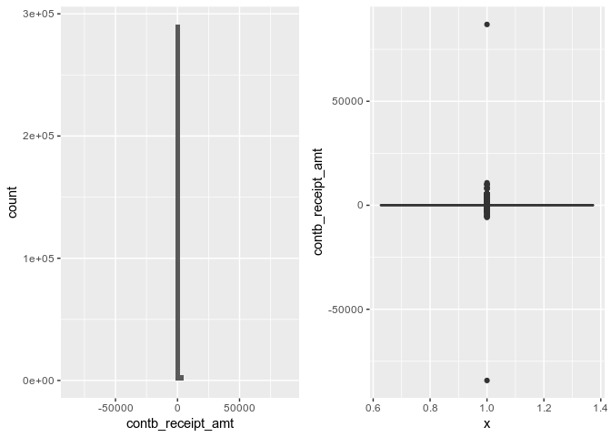

I observed that there were so many outliers(extreme high and extreme low values), it was impossible to see details. And there were negative contributions too.

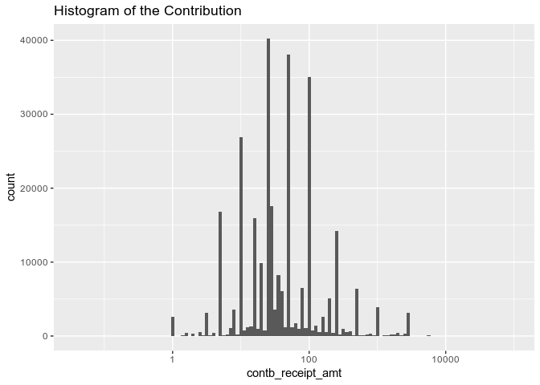

```
##
##     5    10   100    50    25
## 16780 26856 34241 36978 39546
```

```
##     Min.  1st Qu.   Median     Mean  3rd Qu.     Max.
## -84236.8     15.0     28.0    116.1    100.0  86936.8
```

Transforming to log10 to better understand the distribution of the contribution. It looks normal and the data illustrated that most donors made small amount of contributions.

I decided to omit the negative contributions which I believe they were refund and contributions that exceed $2700 limit, because it breaks [Federal Election Campaign Act](http://www.fec.gov/pages/fecrecord/2015/february/contriblimits20152016.shtml) and will be refunded.

```r
sum(ma$contb_receipt_amt >= 2700)
```

```
## [1] 3244
```

```r
sum(ma$contb_receipt_amt < 0)
```

```
## [1] 2653
```

```
##                          cand_nm
## 1               Sanders, Bernard
## 6               Trump, Donald J.
## 7        Clinton, Hillary Rodham
## 13       O'Malley, Martin Joseph
## 194               McMullin, Evan
## 1194   Cruz, Rafael Edward 'Ted'
## 2156               Walker, Scott
## 2158                   Bush, Jeb
## 2284                Rubio, Marco
## 2474    Christie, Christopher J.
## 2485             Kasich, John R.
## 2809                 Stein, Jill
## 3216               Johnson, Gary
## 5487       Webb, James Henry Jr.
## 8623                  Paul, Rand
## 9032              Fiorina, Carly
## 9133        Santorum, Richard J.
## 34369             Huckabee, Mike
## 36388         Graham, Lindsey O.
## 37319          Pataki, George E.
## 43905       Gilmore, James S III
## 47554        Carson, Benjamin S.
## 57970           Lessig, Lawrence
## 110978    Perry, James R. (Rick)
## 221952             Jindal, Bobby
```

```
## # A tibble: 268,895 x 6
##    name  proportion_male proportion_female gender year_min year_max
##    <chr>           <dbl>             <dbl> <chr>     <dbl>    <dbl>
##  1 AARON           0.991            0.0094 male       1920     1997
##  2 AARON           0.991            0.0094 male       1920     1997
##  3 AARON           0.991            0.0094 male       1920     1997
##  4 AARON           0.991            0.0094 male       1920     1997
##  5 AARON           0.991            0.0094 male       1920     1997
##  6 AARON           0.991            0.0094 male       1920     1997
##  7 AARON           0.991            0.0094 male       1920     1997
##  8 AARON           0.991            0.0094 male       1920     1997
##  9 AARON           0.991            0.0094 male       1920     1997
## 10 AARON           0.991            0.0094 male       1920     1997
## # ... with 268,885 more rows
```

After processing the data and I have added 5 new variables to help with the analysis, and removed 5897 observations because they were either negative amount or amount exceed $2700.

The new variables are:

- party: candidates party affilliation.
- contbr_first_nm: contributor’s first name will be used to predict gender.
- gender: contributor’s gender.
- Latitude: Donor’s latitude for map creation.
- Longitute: Donor’s longitude for map creation.

After adding the variables, I am curious what the contribution distribution looks like across the parties, candidates, genders and occupations.

```
## # A tibble: 3 x 5
##   party      sum_party number_of_candidate mean_party      n
##   <chr>          <dbl>               <int>      <dbl>  <int>
## 1 democrat   25832081.                   5   5166416. 243358
## 2 others       270771.                   3     90257.    981
## 3 republican  4605410.                  17    270906.  24556
```

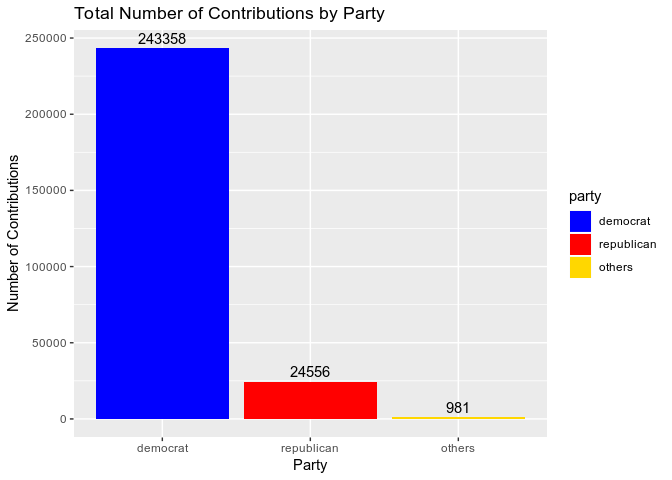

```
## [1] 268895
```

Till November, 2016, total number of donations made to the presidential election amounts to 269K, and the Democratic party took more than 243K and almost 10 times of the number of donations made to the Republican party.

```
##
##                 Bush, Jeb       Carson, Benjamin S.
##                       388                      2591
##  Christie, Christopher J.   Clinton, Hillary Rodham
##                       133                    147534
## Cruz, Rafael Edward 'Ted'            Fiorina, Carly
##                      5624                       469
##      Gilmore, James S III        Graham, Lindsey O.
##                         1                       110
##            Huckabee, Mike             Jindal, Bobby
##                        91                         1
##             Johnson, Gary           Kasich, John R.
##                       457                       755
##          Lessig, Lawrence            McMullin, Evan
##                       130                        20
##   O'Malley, Martin Joseph         Pataki, George E.
##                       269                         3
##                Paul, Rand    Perry, James R. (Rick)
##                       490                         2
##              Rubio, Marco          Sanders, Bernard
##                      1578                     95408
##      Santorum, Richard J.               Stein, Jill
##                        15                       504
##          Trump, Donald J.             Walker, Scott
##                     12256                        49
##     Webb, James Henry Jr.
##                        17
```

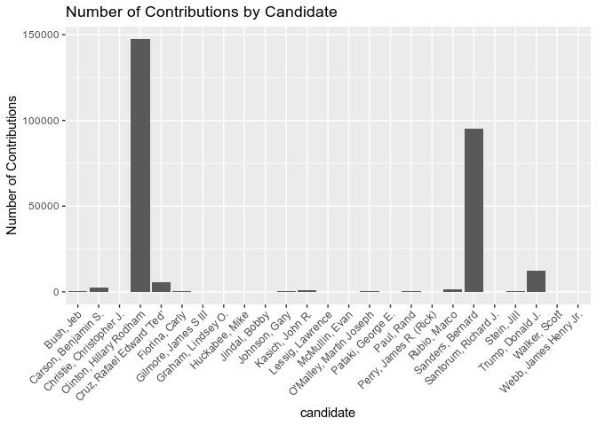

There were total 25 candidates, Hillary Clinton was the leader in the number of contributions, followed by Bernard Sanders, then Donald Trump.

```
## # A tibble: 2 x 3
##   gender   sum_gen  n_gen
##   <chr>      <dbl>  <int>
## 1 female 15029545. 150055
## 2 male   15678717. 118840
```

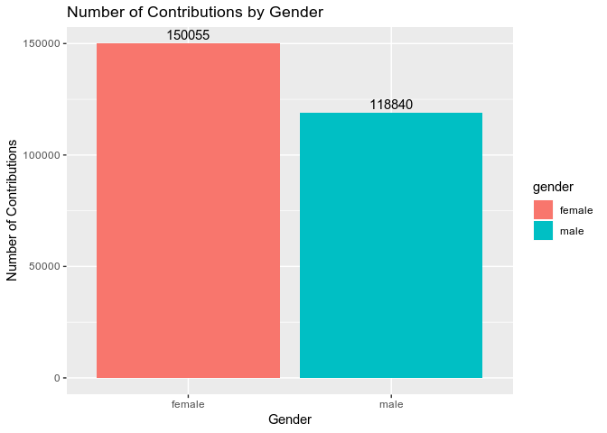

Surprised to know that there were a lot more women than men to made donations.

Who are those donors?

```
## # A tibble: 10 x 4
##    contbr_occupation sum_occu mean_occu     n
##    <ord>                <dbl>     <dbl> <int>
##  1 RETIRED           4480345.     108.  41317
##  2 NOT EMPLOYED      1417174.      53.6 26464
##  3 TEACHER            389587.      56.3  6921
##  4 ATTORNEY          1313684      213.   6182
##  5 PROFESSOR          876505.     143.   6148
##  6 PHYSICIAN          842674.     160.   5263
##  7 CONSULTANT         805574.     192.   4193
##  8 SOFTWARE ENGINEER  361221.      96.5  3744
##  9 HOMEMAKER          686431.     205.   3342
## 10 ENGINEER           309927.      99.7  3109
```

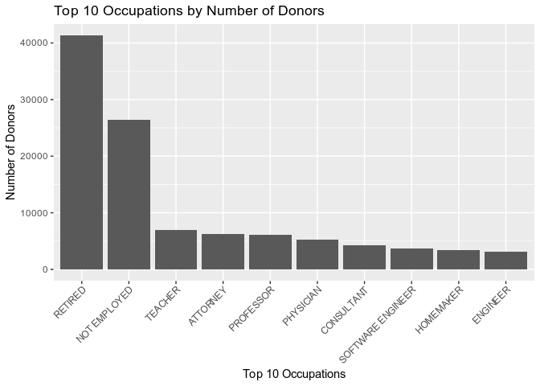

When we count the number of donors, retired people take the first place, followed by unemployed, teacher and attorney.

```
##         Min.      1st Qu.       Median         Mean      3rd Qu.
## "2014-09-25" "2016-03-12" "2016-06-01" "2016-06-01" "2016-09-18"
##         Max.
## "2016-12-30"
```

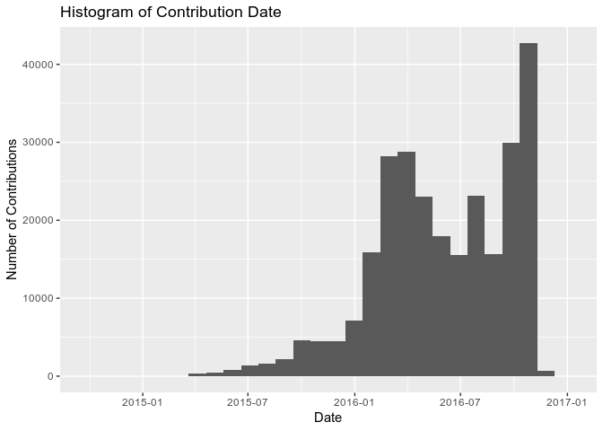

And it is also interesting to see when people made contributions. The date distribution appears bimodal with period peaking around March 2016 or so and again close to the election.

# Bivariate Plots Section

```
## # A tibble: 3 x 5
##   party      sum_party number_of_candidate mean_party      n
##   <ord>          <dbl>               <int>      <dbl>  <int>
## 1 democrat   25832081.                   5   5166416. 243358
## 2 others       270771.                   3     90257.    981
## 3 republican  4605410.                  17    270906.  24556
```

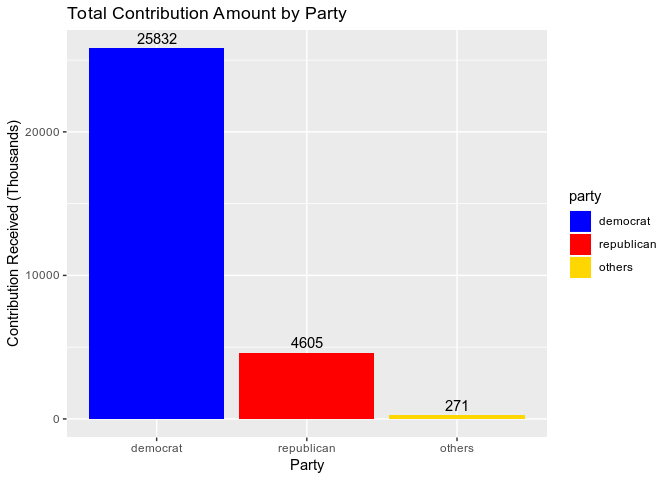

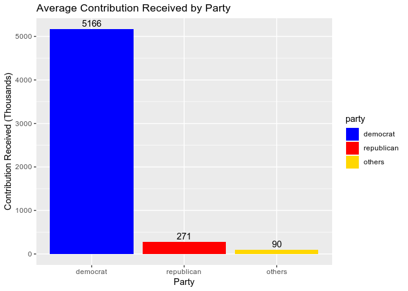

```
## ma$cand_nm
##             Jindal, Bobby    Perry, James R. (Rick)
##                    250.00                    750.00
##      Gilmore, James S III         Pataki, George E.
##                   2700.00                   3950.00
##      Santorum, Richard J.            McMullin, Evan
##                   7620.10                   9305.00
##            Huckabee, Mike     Webb, James Henry Jr.
##                  11048.00                  12100.09
##             Walker, Scott                Paul, Rand
##                  46345.00                  75241.48
##          Lessig, Lawrence            Fiorina, Carly
##                  88483.86                 111371.48
##               Stein, Jill        Graham, Lindsey O.
##                 112948.03                 147830.00
##             Johnson, Gary  Christie, Christopher J.
##                 148518.27                 161570.00
##   O'Malley, Martin Joseph       Carson, Benjamin S.
##                 206496.39                 269372.60
##                 Bush, Jeb           Kasich, John R.
##                 399839.00                 410268.30
## Cruz, Rafael Edward 'Ted'              Rubio, Marco
##                 447206.14                 622812.22
##          Trump, Donald J.          Sanders, Bernard
##                1887235.59                4603428.95
##   Clinton, Hillary Rodham
##               20921571.54
```

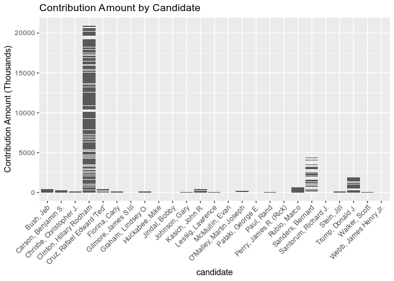

```
## [1] 30708262
```

The total contribution amount made to the presidential candidates grossed over 30 million US dollars in Massachusetts. We can easily see where the money went.

Democratic party takes the majority share of donor contribution. Democratic party got more than 25.8 mollion US dollars in total, which is approximately 6 times of what the Republican received. It is getting worse for the Republican when comes to the average amount, as there were 17 Republican candidates and only 5 Democratic candidates.

Hillary Clinton received the most contribution amount followed by Bernard Sanders then Donald Trump.

There is no surprise as Massachusetts is the home of Kennedy family, and routinely voted for the Democratic party in federal elections.

To see contribution patterns between parties and candidates, Let’s start with boxplots.

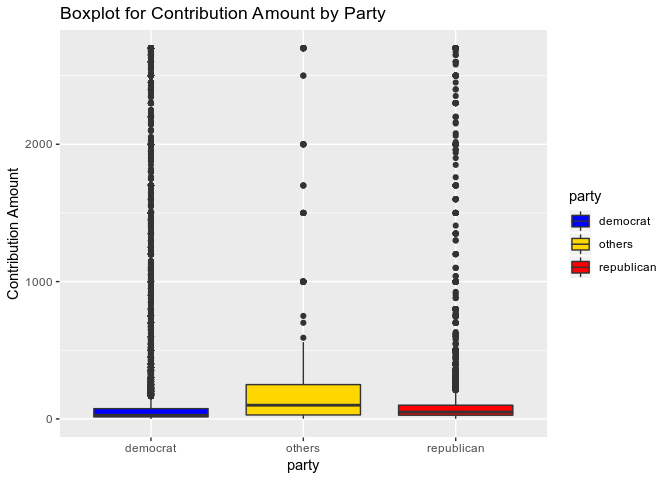

However, it is very hard to compare contributions among all parties due to so many outliers. I will apply log scale and remove the ‘others’ party from now on.

```
## ma$party: democrat
##    Min. 1st Qu.  Median    Mean 3rd Qu.    Max.
##    0.04   15.00   27.00  106.15   75.00 2700.00
## --------------------------------------------------------
## ma$party: republican
##    Min. 1st Qu.  Median    Mean 3rd Qu.    Max.
##    0.80   27.17   50.00  187.55  100.00 2700.00
```

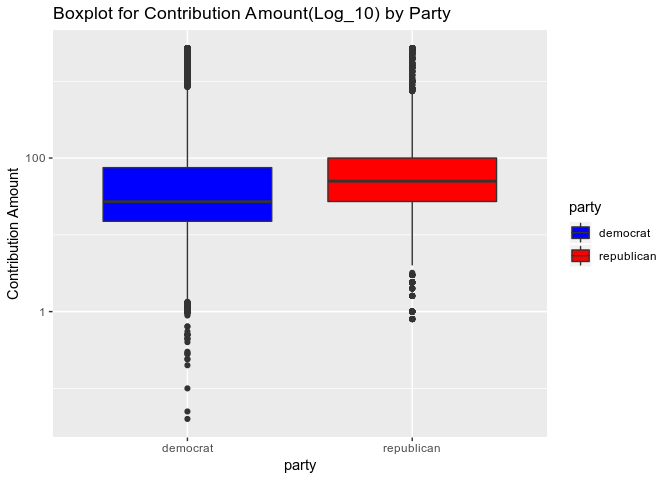

Now it is much better.

Although the Republican has the higher median and mean, the Democrat has more variations and the distribution is more spread out. This indicates that the Democrat has more big and small donors.

```
## ma$cand_nm: Bush, Jeb
##    Min. 1st Qu.  Median    Mean 3rd Qu.    Max.
##       5     100     267    1031    2700    2700
## --------------------------------------------------------
## ma$cand_nm: Carson, Benjamin S.
##    Min. 1st Qu.  Median    Mean 3rd Qu.    Max.
##       1      25      50     104     100    2700
## --------------------------------------------------------
## ma$cand_nm: Christie, Christopher J.
##    Min. 1st Qu.  Median    Mean 3rd Qu.    Max.
##      20     250    1000    1215    2700    2700
## --------------------------------------------------------
## ma$cand_nm: Clinton, Hillary Rodham
##    Min. 1st Qu.  Median    Mean 3rd Qu.    Max.
##    0.04   19.00   36.30  141.81  100.00 2700.00
## --------------------------------------------------------
## ma$cand_nm: Cruz, Rafael Edward 'Ted'
##    Min. 1st Qu.  Median    Mean 3rd Qu.    Max.
##    1.00   25.00   50.00   79.52  100.00 2700.00
## --------------------------------------------------------
## ma$cand_nm: Fiorina, Carly
##    Min. 1st Qu.  Median    Mean 3rd Qu.    Max.
##     3.0    25.0   100.0   237.5   200.0  2700.0
## --------------------------------------------------------
## ma$cand_nm: Gilmore, James S III
##    Min. 1st Qu.  Median    Mean 3rd Qu.    Max.
##    2700    2700    2700    2700    2700    2700
## --------------------------------------------------------
## ma$cand_nm: Graham, Lindsey O.
##    Min. 1st Qu.  Median    Mean 3rd Qu.    Max.
##       5     500    1000    1344    2300    2700
## --------------------------------------------------------
## ma$cand_nm: Huckabee, Mike
##    Min. 1st Qu.  Median    Mean 3rd Qu.    Max.
##     2.0    16.0    50.0   121.4   100.0  2700.0
## --------------------------------------------------------
## ma$cand_nm: Jindal, Bobby
##    Min. 1st Qu.  Median    Mean 3rd Qu.    Max.
##     250     250     250     250     250     250
## --------------------------------------------------------
```

[output cut: 32 more lines]

```
## ma$cand_nm: Santorum, Richard J.
##    Min. 1st Qu.  Median    Mean 3rd Qu.    Max.
##    5.00   17.55  100.00  508.01  500.00 2700.00
## --------------------------------------------------------
## ma$cand_nm: Trump, Donald J.
##    Min. 1st Qu.  Median    Mean 3rd Qu.    Max.
##    0.80   28.00   72.02  153.98  150.00 2700.00
## --------------------------------------------------------
## ma$cand_nm: Walker, Scott
##    Min. 1st Qu.  Median    Mean 3rd Qu.    Max.
##    75.0   250.0   500.0   945.8  1000.0  2700.0
## --------------------------------------------------------
## ma$cand_nm: Webb, James Henry Jr.
##    Min. 1st Qu.  Median    Mean 3rd Qu.    Max.
##   100.0   100.1   250.0   711.8   500.0  2700.0
```

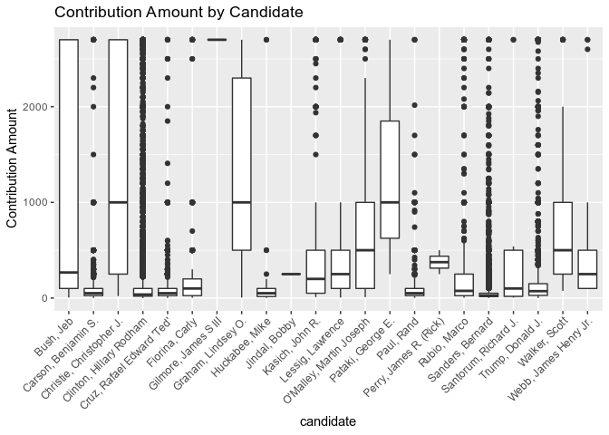

Now let’s check within parties.

```
## # A tibble: 22 x 5
## # Groups:   party [2]
##    party      cand_nm                sum_can mean_can     n
##    <chr>      <chr>                    <dbl>    <dbl> <int>
##  1 republican Jindal, Bobby             250      250      1
##  2 republican Perry, James R. (Rick)    750      375      2
##  3 republican Gilmore, James S III     2700     2700      1
##  4 republican Pataki, George E.        3950     1317.     3
##  5 republican Santorum, Richard J.     7620.     508.    15
##  6 republican Huckabee, Mike          11048      121.    91
##  7 democrat   Webb, James Henry Jr.   12100.     712.    17
##  8 republican Walker, Scott           46345      946.    49
##  9 republican Paul, Rand              75241.     154.   490
## 10 democrat   Lessig, Lawrence        88484.     681.   130
## # ... with 12 more rows
```

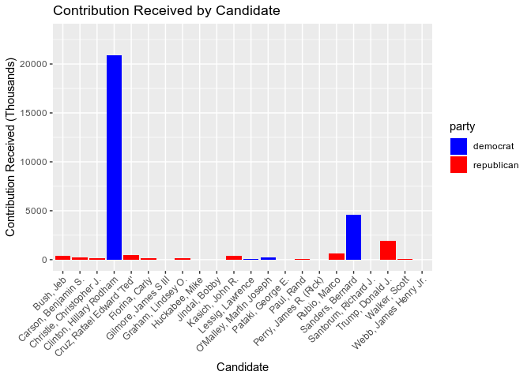

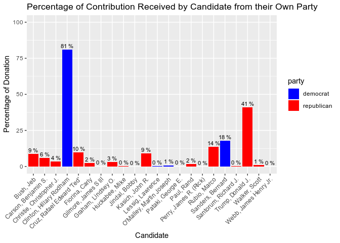

Within each party, majority of the donations were received by only few candidates. For Democratic party, Hillary Clinton and Bernard Sanders take almost 99% of all donations to the Democratic party, and of which, 81% went to Hillary Clinton. For the Republican party, Donald Trump led the way taking 41% of all donations to the Republican party. Donald Trump, Marco Rubio, Ted Cruz, John Kasich, Jeb Bush all together taking 83% of all donations to the Republican party, the remaining 17% were shared by the other 12 Republican candidates.

```
## [1] "Clinton, Hillary Rodham"   "Sanders, Bernard"
## [3] "Trump, Donald J."          "Rubio, Marco"
## [5] "Cruz, Rafael Edward 'Ted'"
```

We have seen earlier that women made 26% more number of contributions than men. Is that the same for the amount of money donated? And do women tend to donate more to the liberals or to woman candidate?

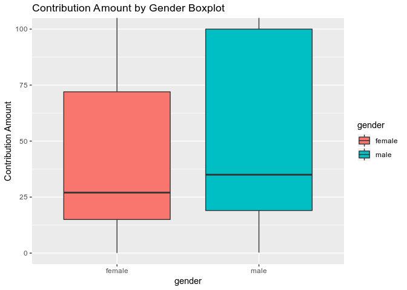

```
## ma$gender: female
##    Min. 1st Qu.  Median    Mean 3rd Qu.    Max.
##    0.04   15.00   27.00   99.78   72.00 2700.00
## --------------------------------------------------------
## ma$gender: male
##    Min. 1st Qu.  Median    Mean 3rd Qu.    Max.
##    0.24   19.00   35.00  131.12  100.00 2700.00
```

On average, male donated $131.12 and female donated $99.78, there is a 31% difference between genders. Female contributed much less than male when we look at median, mean and third quartile.

```
## # A tibble: 2 x 3
##   gender   sum_gen      n
##   <chr>      <dbl>  <int>
## 1 female 14934709. 149682
## 2 male   15502782. 118232
```

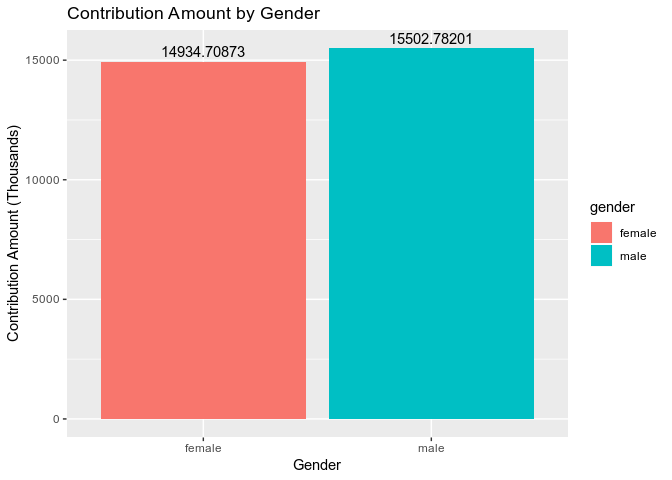

However, when we look at the total contribution amount between genders, they were very close.

```
## # A tibble: 10 x 3
## # Groups:   cand_nm [?]
##    cand_nm                   gender sum_gen_can
##    <chr>                     <chr>        <dbl>
##  1 Clinton, Hillary Rodham   female   11598865.
##  2 Clinton, Hillary Rodham   male      9322707.
##  3 Cruz, Rafael Edward 'Ted' female     137480.
##  4 Cruz, Rafael Edward 'Ted' male       309726
##  5 Rubio, Marco              female     178445.
##  6 Rubio, Marco              male       444368.
##  7 Sanders, Bernard          female    1987549.
##  8 Sanders, Bernard          male      2615880.
##  9 Trump, Donald J.          female     437974.
## 10 Trump, Donald J.          male      1449262.
```

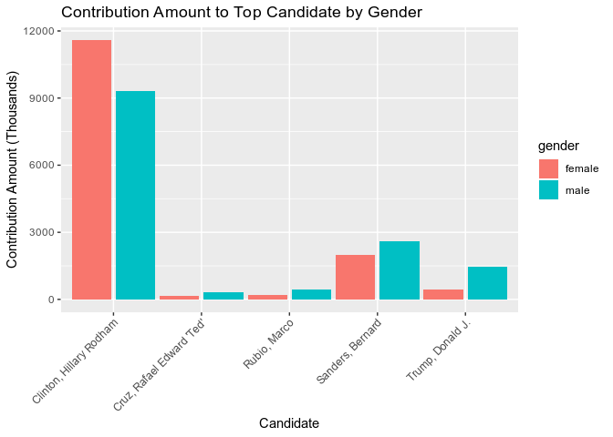

Female in Massachusetts contributed a little less than 15 million US Dollars in total to the presidential campaign in 2016, of which, more than 11 million Dollars went toward Hillary Clinton. This confirms that Massachusetts women donate more to the liberals and/or to woman candidate.

Earlier we have seen that retired people make the most number of contributions, how about total contribution amount and average contribution amount across top 10 occupations?

```
## # A tibble: 10 x 4
##    contbr_occupation sum_occu mean_occu     n
##    <ord>                <dbl>     <dbl> <int>
##  1 RETIRED           4480345.     108.  41317
##  2 NOT EMPLOYED      1417174.      53.6 26464
##  3 TEACHER            389587.      56.3  6921
##  4 ATTORNEY          1313684      213.   6182
##  5 PROFESSOR          876505.     143.   6148
##  6 PHYSICIAN          842674.     160.   5263
##  7 CONSULTANT         805574.     192.   4193
##  8 SOFTWARE ENGINEER  361221.      96.5  3744
##  9 HOMEMAKER          686431.     205.   3342
## 10 ENGINEER           309927.      99.7  3109
```

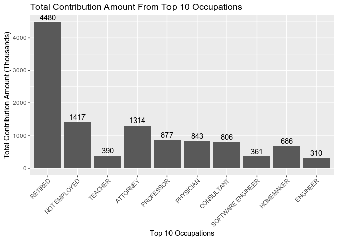

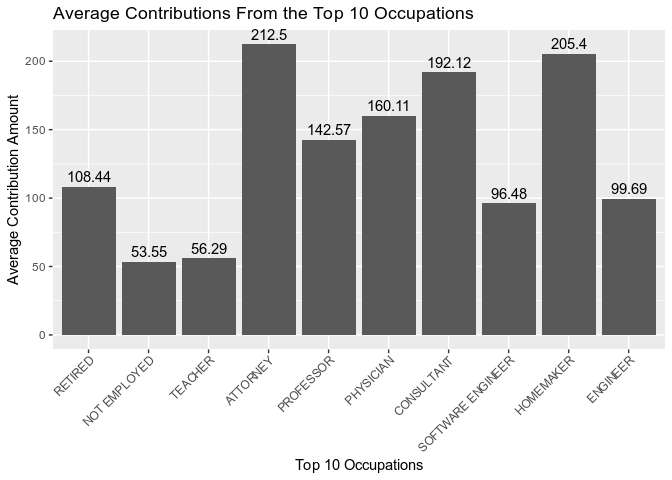

Retirees may make the most number of contributions, but the highest average contributions are attorneys followed by homemakes and consultant. Unemployed, being the least.

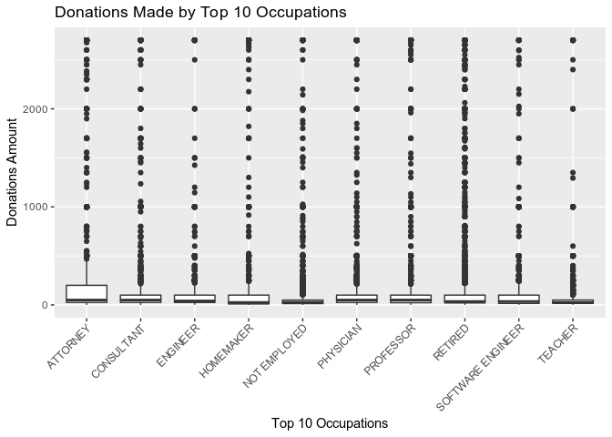

I want to dive deeper to investigate the contribution amount distribution among occupations. But this one is hard to see because there are so many outliers.

```
## top_occu_df$contbr_occupation: ATTORNEY
##    Min. 1st Qu.  Median    Mean 3rd Qu.    Max.
##    0.04   25.00   50.00  212.55  200.00 2700.00
## --------------------------------------------------------
## top_occu_df$contbr_occupation: CONSULTANT
##    Min. 1st Qu.  Median    Mean 3rd Qu.    Max.
##    0.24   25.00   50.00  191.53  100.00 2700.00
## --------------------------------------------------------
## top_occu_df$contbr_occupation: ENGINEER
##    Min. 1st Qu.  Median    Mean 3rd Qu.    Max.
##    1.00   25.00   40.50   98.23  100.00 2700.00
## --------------------------------------------------------
## top_occu_df$contbr_occupation: HOMEMAKER
##    Min. 1st Qu.  Median    Mean 3rd Qu.    Max.
##     1.0    10.0    25.0   202.9   100.0  2700.0
## --------------------------------------------------------
## top_occu_df$contbr_occupation: NOT EMPLOYED
##    Min. 1st Qu.  Median    Mean 3rd Qu.    Max.
##    0.05   13.50   27.00   53.55   50.00 2700.00
## --------------------------------------------------------
## top_occu_df$contbr_occupation: PHYSICIAN
##    Min. 1st Qu.  Median    Mean 3rd Qu.    Max.
##    0.44   25.00   50.00  159.76  100.00 2700.00
## --------------------------------------------------------
## top_occu_df$contbr_occupation: PROFESSOR
##    Min. 1st Qu.  Median    Mean 3rd Qu.    Max.
##    0.45   23.00   50.00  142.20  100.00 2700.00
## --------------------------------------------------------
## top_occu_df$contbr_occupation: RETIRED
##    Min. 1st Qu.  Median    Mean 3rd Qu.    Max.
##     0.5    20.0    35.0   108.1   100.0  2700.0
## --------------------------------------------------------
## top_occu_df$contbr_occupation: SOFTWARE ENGINEER
##    Min. 1st Qu.  Median    Mean 3rd Qu.    Max.
##    1.00   15.00   35.00   93.86  100.00 2700.00
## --------------------------------------------------------
## top_occu_df$contbr_occupation: TEACHER
##    Min. 1st Qu.  Median    Mean 3rd Qu.    Max.
##    0.97   15.00   25.00   56.15   50.00 2700.00
```

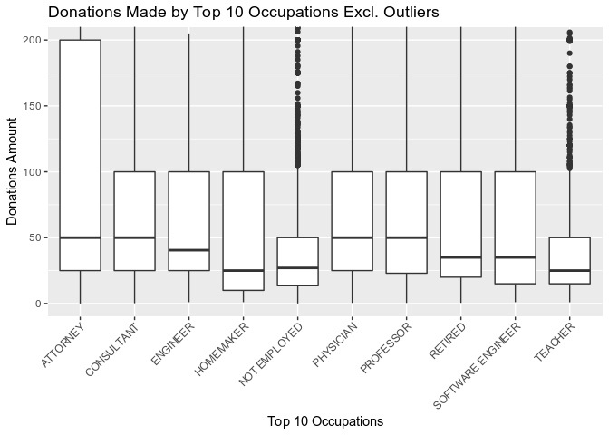

This looks much better. After I filtered out outliers (donations that are extreme high), a boxplot confirms my above observation. The median contribution of teacher, homemaker and unemployed are relatively low.

It is still apparent that attorney made the large contribution with the highest average donation and the largest variability. Some of them contributed 4 times of their respective median.

# Bivariate Analysis

### Talk about some of the interesting findings you observed in this part of the investigation.

- Majority of the total contribution in Massachusetts went towad the Democratic party.
- There were 5 Democratic candidates and 17 Republican candidates. Therefore, there is even bigger difference when we compare average amount between parties.
- Within each party, the majority of contributions are received by a few candidates.
- In Massachusetts there are more female donors than male donors, but female donate much less than male on average.
- In Massachusetts, majority of the contributions from female donors went toward Democratic party and/or woman candidate.
- Retired people contribute the most in total amount, and software engineers and engineers are among the least in total contribution amount.
- Attorneys had the highest average contribution amount and greatest interquartile range, unemployed people have the lowest average contribution amount and one of the smallest interquartile ranges.

### Did you observe any interesting relationships between the other features (not the main feature(s) of interest)?

Surprisingly, homemakers had the 2nd highest average contribution amount, but the median contribution in this group is among the lowest. It suggests that the distribution of the data is right skewed with many outliers. Also my presumption is that majority of the homemakers are women.

### What was the strongest relationship you found?

Men had higher donation amount than women.

# Multivariate Plots

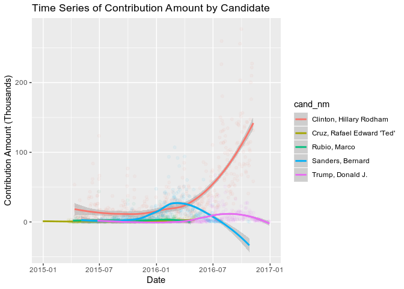

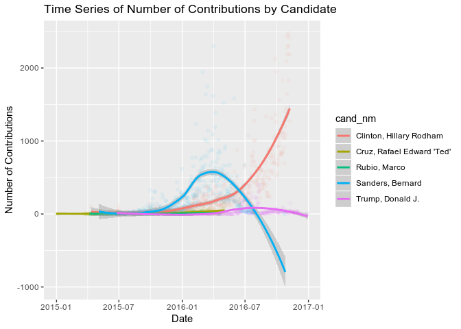

We know that Hillary Clinton raised the most money and had the most supporters in Massachusetts. But is this always true throughout the campaign process? When I look at above 2 graphs, I notice 2 things:

1. Bernard Sanders actually raised more money than Hillary Clinton started from January 2016 lasted for a few months.
2. Bernard Sanders actually had more supporters than Hillary Clinton from January 2016 onward until June 2016 when he announced to endorse Hillary Clinton that broke his supporters’ hearts.

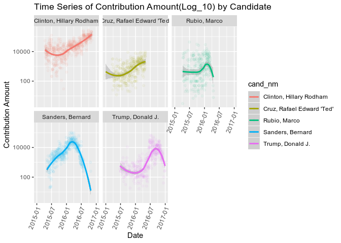

As a side note, although Donald Trump did not win in Massachusetts, [A Third of Massachusetts Voters Picked Trump](http://www.bostonmagazine.com/news/blog/2016/11/10/massachusetts-trump-voters/) and [The Trump effect happened in Massachusetts, too](https://www.bostonglobe.com/metro/2016/11/13/the-trump-effect-happened-massachusetts-too/fOGkVgbSQ2LHpuixIHxi0H/story.html).

Where do those donors reside?

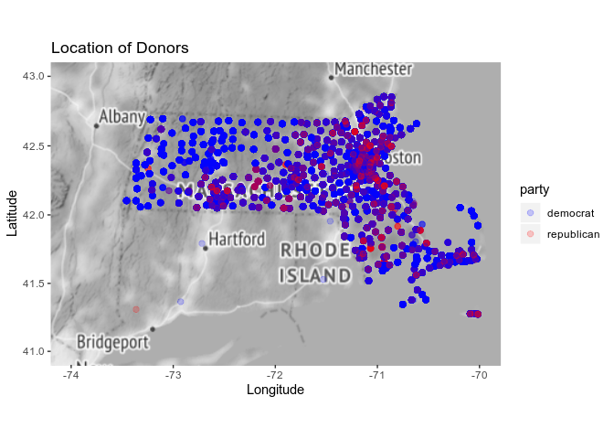

It looks like more republicans concentrated around Boston area, this does make sense as Boston is the largest city in Massachusetts.

# Multivariate Analysis

### Talk about some of the relationships you observed in this part of the investigation.

- While closer to the election, more big pocket donors supported Hillary Clinton.
- While closer to the election, less donation went toward Donald Trump.

### Were there any interesting or surprising findings?

For a certain period of time, Bernard Sanders received more donations and gained more popularity than Hillary Clinton.

## Final Plots and Summary

### Most Donations went toward a few candidates.

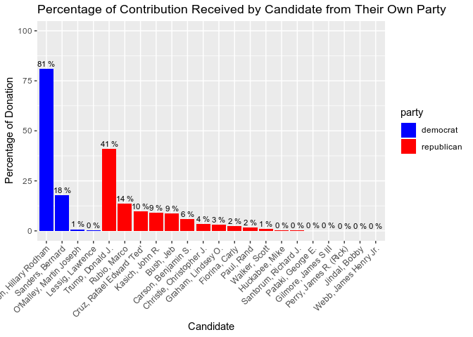

In Massachusetts, the financial donations to the presidential campaign were distributed unevenly. Especially in Democrat, 99% of the donations for Democrat went to two candidates and Hillary Clinton took 81%. It is obvious that Massachusetts is among the bluest of states.

## Contribution by Occupation

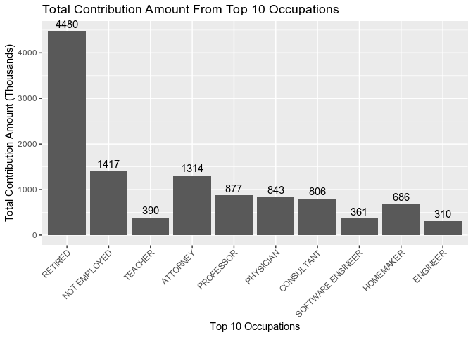

The total contribution across occupations differ substantially. If I was asked which occupation contributed the most to presidential candidates in Massachusetts in 2016, I would have guessed ‘attorneys’ or ‘CEOs’. Wrong.

The top occupation isn’t really an ‘occupation’, but individuals who lists their occupation as ‘retired’ in federal documents. Unlike attorneys or consultants whose donations may covered by their companies, retired people more likely pay from their own pockets.

It continues to surprise me that software engineer among the lowest in total contribution, considering their presumably above average salary. But any further conclusion requires better knowledge of industry political background.

### Time Series of Top Candidates

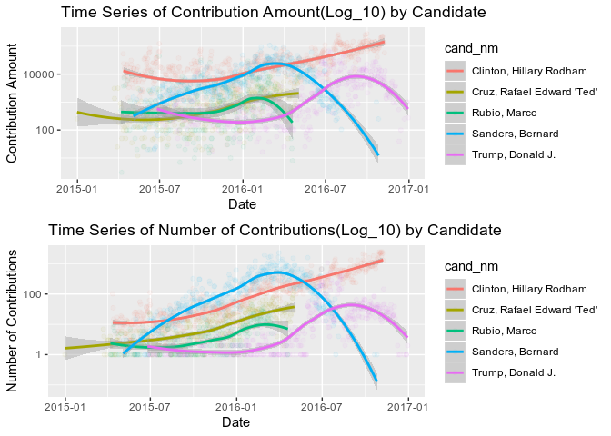

Hillary Clinton dominated the contribution amount and number of contributions, the closer to the election, the more supporters with more money came to her.

On the other hand, Bernard Sanders had a steady growth in terms of donation amount and number of donors, until he gave up his run.

## Reflection

### Challenges and Struggles

- The original dataset did not contain gender information, to analyze the relationship between gender and donations, I added gender column using R’s gender package which used to predict gender from donor’s first name.
- To see a better picture of donors’ geographic location, I added latitude and longitude columns using zipcode package and I was able to create a map using ggmap after that.
- I chose to omit negative contributions and contributions that exceed $2700 because of the Contribution Limits for 2015-2016 Federal Elections.
- I am not familar with ggmap and spent a lot of time on them.

### Success

- The ggplot2 and dplyr packages are the most important packages for this project. I also learned gender and zipcode packages and found they are powerful.
- I learned a lot of new things throughout this project. Thanks to [ggmap quickstart](https://www.nceas.ucsb.edu/~frazier/RSpatialGuides/ggmap/ggmapCheatsheet.pdf), [R-bloggers](https://www.r-bloggers.com/how-to-perform-a-logistic-regression-in-r/) and [Logistic Regression in R tutorial](https://www.youtube.com/watch?v=mteljf020EE) to make my project possible. It was a great experience.

### Future Work

The analysis I conducted is for Massachusetts state only. It would be interesting to analyze campaign finance data for more states, as well as campaign finance data nationwide. I am sure we will see things differently as data tends to surprise us.